# Oxygen project using eICU data

Willem van den Boom

August 17, 2018

```r
if(!require(bigrquery)) {
  install.packages("bigrquery")
  library("bigrquery")
}
```

```r
# Project ID from Google Cloud
project_id <- "oxygenators-209612"
options(httr_oauth_cache=FALSE)

# Wrapper for running BigQuery queries.
run_query <- function(query){
    data <- query_exec(query, project=project_id, use_legacy_sql = FALSE, max_pages = Inf)
    return(data)
}

# Library for fitting generalized additive models (GAMs)
library(mgcv)
if(!require(mgcv)) {
  install.packages("mgcv")
  library("mgcv")
}
```

# Read in data from eICU

```r
patient <- run_query('
SELECT * FROM eicu.final_patient_results
')

O2measurement <- run_query('
SELECT * FROM eicu.final_measurement_results
')
```

# Data preprocessing

## Gender

Transform gender to a factor rather than string Set genders that are neither male nor female as missing, effectively excluding these from the analysis

```r
if(is.character(patient$gender)) patient$gender_string <- patient$gender
summary(as.factor(patient$gender_string))
```

```
##          Female    Male   Other Unknown
##     134   92303  108379       8      35
```

```r
patient$gender <- NA
patient$gender[patient$gender_string == "Female"] = "F"
patient$gender[patient$gender_string == "Male"] = "M"

patient$gender = as.factor(patient$gender)
```

## ICU type

### From Slack

*Mornin Feng* The followings are my suggestions: 1/ Just exclude Neuro ICUS 2/ Merge “Cardiac ICU” “CCU-CTICU”: Coronary Care Unit / Cardiothoracic ICU “CTICU”: Cardiothoracic ICU as CCUs, BUT keep “CSICU”: Cardiac Surgery ICU separately as CSICU 3/ MICU and SICU should not be merged 4/ Med-Surg ICU, KC See what do you think? (edited)

*KC See* I largely agree with Mornin. The Neuro ICU is unclear what it is - Medical Neuro vs Neurosurgical. For CSICU, I think it is like CTICU. Can we do analysis with and without it, and see if there is a difference? MICU, MSICU, and SICU should be separate. Then if all shows similar results, we can pool everything too

```r
patient$unit_type = as.factor(patient$unittype)

#levels(patient$unit_type)[levels(patient$unit_type) %in% c("Med-Surg ICU", "MICU", "SICU")] = "General ICU"
levels(patient$unit_type)[levels(patient$unit_type) %in% c("CCU-CTICU", "CSICU", "CTICU")] = "Cardiac ICU"
```

## Determine first stay

We use `hospitalDischargeYear` and `unit_stay_number` to determine whether an ICU stay was a patient’s first.

```r
patient$first_stay = NA
patient$first_stay[patient$unit_stay_number > 1] <- FALSE

tmp_table = table(patient$patient_ID[is.na(patient$first_stay)])

# An ICU stay that is a patient's only one with `unit_stay_number` = 1
# must be a first stay.
patient$first_stay[
  is.na(patient$first_stay) &
  patient$patient_ID %in%
  names(tmp_table)[tmp_table == 1]
] <- TRUE

# `hospitalDischargeYear` only takes the values 2014 and 2015
unique(patient$hospitalDischargeYear)
```

```
## [1] 2015 2014
```

```r
# The remaning NAs in first_stay can only be resolved if a patient
# has only 1 hospital stay with a discharge in 2014
tmp_IDs <- names(tmp_table[tmp_table > 1])

for(id in tmp_IDs) {
  tmp_index = which(
    patient$patient_ID == id &
    is.na(patient$first_stay) &
    patient$hospitalDischargeYear == 2014
  )

  if(length(tmp_index) == 1) patient$first_stay[tmp_index] <- TRUE
}

rm(tmp_table, tmp_IDs, tmp_index, id)

summary(patient$first_stay)
```

```
##    Mode   FALSE    TRUE    NA's
## logical   42417  120106   38336
```

# Oxygen measurements

We remove oxygen measurements that are outside of the range [10, 100]

```r
O2measurement <- O2measurement[O2measurement$spO2_Value <= 100 & O2measurement$spO2_Value >= 10,]
```

Count the number of oxygen measurements per ICU stay Since we only need these counts for the first ICU stay, we constrain ourselves to this subset for speed.

```r
tmp <- unique(O2measurement$icustay_id)
tmp <- tmp[!(tmp %in% patient$icustay_id[patient$first_stay])]
tmp <- table(O2measurement$icustay_id, exclude = tmp)

patient$nOxy <- as.numeric(tmp[match(patient$icustay_id, names(tmp))])
rm(tmp)

# ICU stays that do not have any measurements are currently NA and should be 0.
patient$nOxy[which(is.na(patient$nOxy) & patient$first_stay)] <- 0

mean(patient$nOxy[which(patient$first_stay)] >= 72)
```

```
## [1] 0.2849316
```

# Subset selection

The following code selects cases of interest while also providing the info required for a flow diagram: That is, how many patients did not meet the inclusion criteria.

```r
cat("Total number of ICU stays:", nrow(patient))
```

```
## Total number of ICU stays: 200859
```

```r
# We only keep first stays
tmp <- which(patient$first_stay)
cat("\nNumber of first stays:", length(tmp))
```

```
##
## Number of first stays: 120106
```

```r
cat("\nNumber of patients for whom we couldn't determine first stays:", length(unique(patient$patient_ID[is.na(patient$first_stay)])))
```

```
##
## Number of patients for whom we couldn't determine first stays: 17563
```

```r
patient_subset <- patient[tmp,]



cat("Number of selected patients so far:", nrow(patient_subset))
```

```
## Number of selected patients so far: 120106
```

```r
# Ages above 89 are recorded as "> 89" in the eICU data
# The current SQL code translates "> 89" to "89" such that we cannot distinguish between 89 and >89.
# As we use age as a confounder, we remove those with age 89.
# We only consider "adults" (age >= 16).
tmp <- patient_subset$age < 16 | patient_subset$age == 89
cat("\nPatients outside age range:", sum(tmp, na.rm = TRUE))
```

```
##
## Patients outside age range: 6265
```

```r
cat("\nPatients with missing age:", sum(is.na(tmp)))
```

```
##
## Patients with missing age: 76
```

```r
tmp[is.na(tmp)] <- TRUE

# `delete` records which cases to delete from patient
delete <- tmp

# Delete those whose gender is unknown or other
tmp <- is.na(patient_subset$gender)
cat("\nPatients with missing or 'other' gender:", sum(tmp))
```

```
##
## Patients with missing or 'other' gender: 140
```

```r
delete <- delete | tmp

cat("\nPatients selected so far:", sum(!delete))
```

```
##
## Patients selected so far: 113726
```

```r
# Delete those with fewer than 72 oxygen measurements
tmp <- patient_subset$nOxy < 72
cat("\nPatients with too few measurements:", sum(tmp), "out of", nrow(patient_subset))
```

```
##
## Patients with too few measurements: 85884 out of 120106
```

```r
delete <- delete | tmp


patient_subset <- patient_subset[!delete,]
cat("\nPatients selected:", nrow(patient_subset))
```

```
##
## Patients selected: 32732
```

```r
rm(delete)
```

We only keep hospitals with at least 100 cases

```r
cat("\n Number of hospitals in current subset:", length(unique(patient_subset$hospital_id)))
```

```
##
##  Number of hospitals in current subset: 144
```

```r
tmp <- table(patient_subset$hospital_id)
cat("\n Number of hospitals with at least 100 patients:", sum(tmp >= 100))
```

```
##
##  Number of hospitals with at least 100 patients: 66
```

```r
delete <- patient_subset$hospital_id %in% as.numeric(names(tmp[tmp < 100]))
patient_subset <- patient_subset[!delete,]
patient_subset$hospital_id = as.factor(patient_subset$hospital_id)

cat("\n Number of patients in selected subset:", nrow(patient_subset))
```

```
##
##  Number of patients in selected subset: 30156
```

## Cleaning

```r
patient_subset$patientunitstayid <- NULL # Duplicates icustay_id

# Cases with no diagnoses from ICD-9 codes have all diagnoses as "NA"
# These should be FALSE.
for(j in which(grepl("has_", names(patient_subset)))) {
  patient_subset[is.na(patient_subset[,j]), j] <- FALSE
}
rm(j)
```

## Demographics

Let us compare the demographics before and after the subset selection.

```r
# Variables of which we like summaries
tmp <- c('age', 'gender', 'unit_type', 'nOxy', 'mortality_in_ICU')

cat("Mortality in 'patient':", sum(patient$mortality_in_ICU), "\n")
```

```
## Mortality in 'patient': 10941
```

```r
summary(patient[patient$age >= 16,tmp])
```

```
##       age         gender              unit_type           nOxy
##  Min.   :16.00   F   : 92222   Cardiac ICU : 43522   Min.   :    0.00
##  1st Qu.:53.00   M   :108273   Med-Surg ICU:113004   1st Qu.:    4.00
##  Median :65.00   NA's:   183   MICU        : 17442   Median :   32.00
##  Mean   :63.09                 Neuro ICU   : 14444   Mean   :   71.76
##  3rd Qu.:76.00                 SICU        : 12171   3rd Qu.:   82.00
##  Max.   :89.00                 NA's        :    95   Max.   :10364.00
##  NA's   :95                                          NA's   :80791
##  mortality_in_ICU
##  Min.   :0.0000
##  1st Qu.:0.0000
##  Median :0.0000
##  Mean   :0.0545
##  3rd Qu.:0.0000
##  Max.   :1.0000
##  NA's   :95
```

```r
cat("Mortality in 'patient_subset':", sum(patient_subset$mortality_in_ICU), "\n")
```

```
## Mortality in 'patient_subset': 2288
```

```r
summary(patient_subset[,tmp])
```

```
##       age        gender           unit_type          nOxy
##  Min.   :16.00   F:13269   Cardiac ICU : 8376   Min.   :   72.0
##  1st Qu.:54.00   M:16887   Med-Surg ICU:11492   1st Qu.:   95.0
##  Median :65.00             MICU        : 3253   Median :  134.0
##  Mean   :62.89             Neuro ICU   : 4241   Mean   :  202.5
##  3rd Qu.:75.00             SICU        : 2794   3rd Qu.:  221.0
##  Max.   :88.00                                  Max.   :10364.0
##  mortality_in_ICU
##  Min.   :0.00000
##  1st Qu.:0.00000
##  Median :0.00000
##  Mean   :0.07587
##  3rd Qu.:0.00000
##  Max.   :1.00000
```

# Compute summaries of oxygen measurements

We compute the median oxygen level and the proportion of measurements within 94% to 97% oxygen saturation. We do this after subset selection as it is much faster to compute these only for the subset of interest.

We currently ignore the time aspect of the measurements. However, one should probably take into account that certain measurements are less spread out than others.

```r
patient_subset$median <- NA
patient_subset$prop <- NA
n <- nrow(patient_subset)
pb <- txtProgressBar(max = n, style = 3)

for(i in 1:n) {
  tmp <- O2measurement$spO2_Value[O2measurement$icustay_id == patient_subset$icustay_id[i]]

  patient_subset$median[i] <- median(tmp)
  patient_subset$prop[i] <- mean(tmp >= 94 & tmp <= 97)

  setTxtProgressBar(pb, i)
}
close(pb)
rm(i,tmp,pb)

summary(patient_subset$median)
summary(patient_subset$prop)
```

[output not shown]

Plot some basic comparison of the two outcome groups.

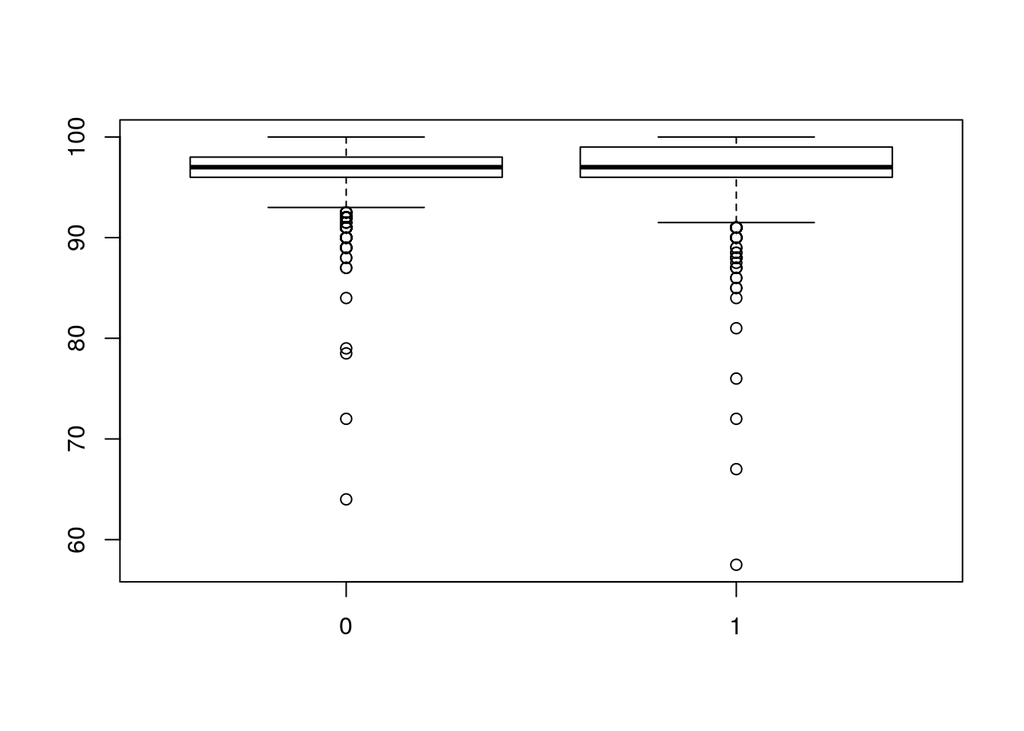

```r
boxplot(patient_subset$median ~ patient_subset$mortality_in_ICU)
```

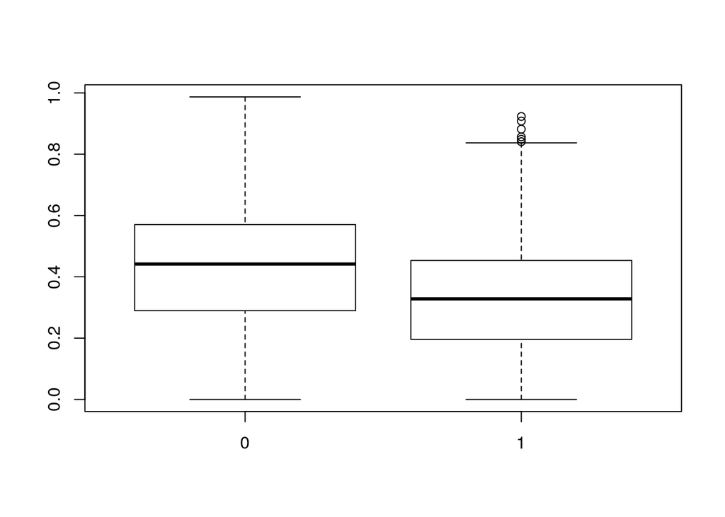

```r
boxplot(patient_subset$prop ~ patient_subset$mortality_in_ICU)
```

# Model fitting

## Median of measurements

We fit a generalized additive model (GAM) to check for the effect of the median oxygen saturation. GAMs are regression models that allow for nonlinear effects of the predictors. We add gender and age as predictors to control for them. We also control for hospital but since there are so many hospitals, we add it as a random effect.

```r
logistic <- function(x) 1/(1+exp(-x))
```

```r
gamfitMed <- gamm(mortality_in_ICU ~ s(median)+gender+s(age), data = patient_subset, family = binomial, random = list(hospital_id = ~ 1))$gam
```

```
##
##  Maximum number of PQL iterations:  20
```

```
## iteration 1
```

```
## iteration 2
```

```
## iteration 3
```

```
## iteration 4
```

```
## iteration 5
```

```
## iteration 6
```

```
## iteration 7
```

```
## iteration 8
```

```
## iteration 9
```

```
## iteration 10
```

```r
summary(gamfitMed)
```

```
##
## Family: binomial
## Link function: logit
##
## Formula:
## mortality_in_ICU ~ s(median) + gender + s(age)
##
## Parametric coefficients:
##             Estimate Std. Error t value Pr(>|t|)
## (Intercept) -2.63239    0.07547 -34.880   <2e-16 ***
## genderM      0.05665    0.04493   1.261    0.207
## ---
## Signif. codes:  0 '***' 0.001 '**' 0.01 '*' 0.05 '.' 0.1 ' ' 1
##
## Approximate significance of smooth terms:
##             edf Ref.df     F  p-value
## s(median) 6.009  6.009 62.54  < 2e-16 ***
## s(age)    1.000  1.000 45.78 1.34e-11 ***
## ---
## Signif. codes:  0 '***' 0.001 '**' 0.01 '*' 0.05 '.' 0.1 ' ' 1
##
## R-sq.(adj) =  0.0188
##   Scale est. = 1         n = 30156
```

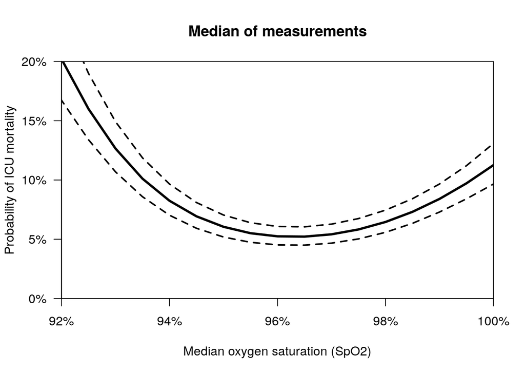

```r
xRange = c(92, 100)
yRange = c(0, .2)

xlab <- "Median oxygen saturation (SpO2)"
ylab <- "Probability of ICU mortality"

xName <- "median"

main <- "Median of measurements"

# Color for dotted line
colD <- "Black"

    plot(1, type = 'n', xlim = xRange, ylim = yRange,
         ylab = ylab,
         xlab = xlab, main = main, yaxs = 'i', xaxs = 'i', yaxt = 'n', xaxt = 'n')

    att <- pretty(yRange)
if(!isTRUE(all.equal(att, round(att, digits = 2)))) {
  axis(2, at = att, lab = paste0(sprintf('%.1f', att*100), '%'), las = TRUE)
} else axis(2, at = att, lab = paste0(att*100, '%'), las = TRUE)

    att <- pretty(xRange)
    axis(1, at = att, lab = paste0(att, '%'), las = TRUE)


    eval(parse(text = paste(c('predictionsPlusCI <- predict(gamfitMed, newdata = data.frame(',
                              xName, ' = gamfitMed$model$', xName, ", gender = 'F', age = median(gamfitMed$model$age), hospital_id = 264), type = 'link', se.fit = T)"), collapse = "")))


  # We have to use the data on which GAM was fit for confidence region as the GAM does not provide standard errors for 'new' input
  eval(parse(text = paste0('xx <- gamfitMed$model$', xName)))
  ord.index <- order(xx)
  xx <- xx[ord.index]

  if(gamfitMed$family$link == 'logit') {
    lcl <- logistic(predictionsPlusCI$fit[ord.index] - 1.96*predictionsPlusCI$se.fit[ord.index])
    ucl <- logistic(predictionsPlusCI$fit[ord.index] + 1.96*predictionsPlusCI$se.fit[ord.index])

    lines(x = xx, y = lcl, lty = 2, lwd = 2, col = colD)
    lines(x = xx, y = ucl, lty = 2, lwd = 2, col = colD)
    lines(xx, logistic(predictionsPlusCI$fit[ord.index]), lwd = 3)
  } else {
    lcl <- predictionsPlusCI$fit[ord.index] - 1.96*predictionsPlusCI$se.fit[ord.index]
    ucl <- predictionsPlusCI$fit[ord.index] + 1.96*predictionsPlusCI$se.fit[ord.index]

    lines(x = xx, y = lcl, lty = 2, lwd = 2)
    lines(x = xx, y = ucl, lty = 2, lwd = 2)
    lines(xx, predictionsPlusCI$fit[ord.index], lwd = 3)
  }
```

## Proportion of measurements within range

We now fit a GAM with the proportion of measurements within a range instead of the median of the measurements.

```r
gamfitProp <- gamm(mortality_in_ICU ~ s(prop)+gender+s(age), data = patient_subset, family = binomial, random = list(hospital_id = ~ 1))$gam
```

```
##
##  Maximum number of PQL iterations:  20
```

```
## iteration 1
```

```
## iteration 2
```

```
## iteration 3
```

```
## iteration 4
```

```r
summary(gamfitProp)
```

```
##
## Family: binomial
## Link function: logit
##
## Formula:
## mortality_in_ICU ~ s(prop) + gender + s(age)
##
## Parametric coefficients:
##             Estimate Std. Error t value Pr(>|t|)
## (Intercept) -2.74439    0.07399 -37.090   <2e-16 ***
## genderM      0.11283    0.04498   2.508   0.0121 *
## ---
## Signif. codes:  0 '***' 0.001 '**' 0.01 '*' 0.05 '.' 0.1 ' ' 1
##
## Approximate significance of smooth terms:
##           edf Ref.df      F  p-value
## s(prop) 4.742  4.742 108.61  < 2e-16 ***
## s(age)  1.000  1.000  58.16 2.49e-14 ***
## ---
## Signif. codes:  0 '***' 0.001 '**' 0.01 '*' 0.05 '.' 0.1 ' ' 1
##
## R-sq.(adj) =  0.0215
##   Scale est. = 1         n = 30156
```

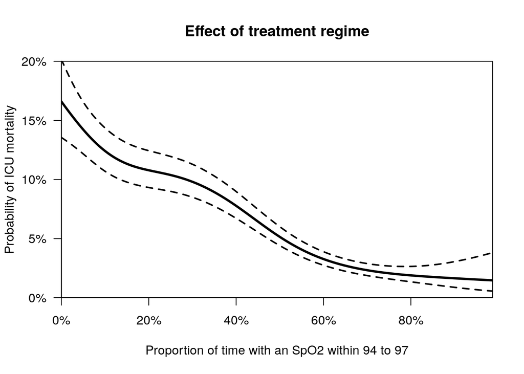

```r
logistic <- function(x) 1/(1+exp(-x))
xRange = c(0, max(patient_subset$prop, na.rm= TRUE))
yRange = c(0, .2)

xlab <- "Proportion of time with an SpO2 within 94 to 97"
ylab <- "Probability of ICU mortality"

xName <- "prop"

main <- "Effect of treatment regime"

    plot(1, type = 'n', xlim = xRange, ylim = yRange,
         ylab = ylab,
         xlab = xlab, main = main, yaxs = 'i', xaxs = 'i', yaxt = 'n', xaxt = 'n')

    att <- pretty(yRange)
if(!isTRUE(all.equal(att, round(att, digits = 2)))) {
  axis(2, at = att, lab = paste0(sprintf('%.1f', att*100), '%'), las = TRUE)
} else axis(2, at = att, lab = paste0(att*100, '%'), las = TRUE)

    att <- pretty(xRange)
    axis(1, at = att, lab = paste0(att*100, '%'), las = TRUE)


    eval(parse(text = paste(c('predictionsPlusCI <- predict(gamfitProp, newdata = data.frame(',
                              xName, ' = gamfitProp$model$', xName, ", gender = 'F', age = median(gamfitProp$model$age)), type = 'link', se.fit = T)"), collapse = "")))


  # We have to use the data on which GAM was fit for confidence region as the GAM does not provide standard errors for 'new' input
  eval(parse(text = paste0('xx <- gamfitProp$model$', xName)))
  ord.index <- order(xx)
  xx <- xx[ord.index]

  if(gamfitProp$family$link == 'logit') {
    lcl <- logistic(predictionsPlusCI$fit[ord.index] - 1.96*predictionsPlusCI$se.fit[ord.index])
    ucl <- logistic(predictionsPlusCI$fit[ord.index] + 1.96*predictionsPlusCI$se.fit[ord.index])

    lines(x = xx, y = lcl, lty = 2, lwd = 2)
    lines(x = xx, y = ucl, lty = 2, lwd = 2)
    lines(xx, logistic(predictionsPlusCI$fit[ord.index]), lwd = 3)
  } else {
    lcl <- predictionsPlusCI$fit[ord.index] - 1.96*predictionsPlusCI$se.fit[ord.index]
    ucl <- predictionsPlusCI$fit[ord.index] + 1.96*predictionsPlusCI$se.fit[ord.index]

    lines(x = xx, y = lcl, lty = 2, lwd = 2)
    lines(x = xx, y = ucl, lty = 2, lwd = 2)
    lines(xx, predictionsPlusCI$fit[ord.index], lwd = 3)
  }
```

## Odds ratios

Based on the model fits, we can estimate odds ratios, including 95% confidence intervals.

```r
if(!require("oddsratio")) {
  install.packages("oddsratio")
  library(oddsratio)
}
tmp <- or_gam(data = patient_subset, model = gamfitMed, pred = "median", values = c(96, 100))

cat(
  "The odds ratio of mortality for a median oxygen saturation at 100% versus 96% is ",
  tmp$oddsratio,
  " (95% CI ",
  tmp$`CI_high (97.5%)`,
  " to ",
  tmp$`CI_low (2.5%)`,
  ").",
  sep = ""
)
```

[output not shown]

```r
tmp <- or_gam(data = patient_subset, model = gamfitProp, pred = "prop", values = c(.8, .4))

cat(
  "The odds ratio of mortality for a proportion of measurements within the range at 40% versus 80% is ",
  tmp$oddsratio,
  " (95% CI ",
  tmp$`CI_low (2.5%)`,
  " to ",
  tmp$`CI_high (97.5%)`,
  ").",
  sep = ""
)
```

```
## The odds ratio of mortality for a proportion of measurements within the range at 40% versus 80% is 4.380144 (95% CI 3.616268 to 5.305377).
```